# Contact tracing

THIS PAGE IS UNDER CONSTRUCTION

This page walks through some key considerations when analyzing and visualizing contact tracing data. Many core R competencies and tools are covered in other sections as the same desired functionalities apply (i.e. data cleaning; pivoting; tables; time-series analyses) but we will highlight key examples specific to contact tracing that have been useful for operational decision making. This would include things like visualizing contact tracing follow-up data over time or across geographic areas, or producing clean KPI tables for Contact Tracing supervisors.

For demonstration purposes we will be reading in sample contact tracing data from the [Go.Data](https://www.who.int/tools/godata) platform; although the same principles could apply for other structured contact tracing data. You can read more about the Go.Data project on the [Github Documentation site](https://worldhealthorganization.github.io/godata/) or [Community of Practice](https://community-godata.who.int/).

## Preparation

This code chunk shows the loading of packages required for the analyses. In this handbook we emphasize `p_load()` from **pacman**, which installs the package if necessary *and* loads it for use. You can also load installed packages with `library()` from **base** R. See the page on [R basics] for more information on R packages.

```r
pacman::p_load(
  rio,        # importing data
  here,       # relative file pathways
  janitor,    # data cleaning and tables
  lubridate,  # working with dates
  epikit,     # age_categories() function
  apyramid,   # age pyramids
  tidyverse,  # data manipulation and visualization
  RColorBrewer, # color palettes
  formattable, # fancy tables
  kableExtra # table formatting
)
```

### Import data

We will import the sample datasets of contacts and contact followups that have been retrieved and un-nested from the Go.Data API and stored as .rds output files.

[figure not shown]

If you want to follow along, [click to download the "clean" linelist](https://github.com/appliedepi/epirhandbook_eng/raw/master/data/case_linelists/linelist_cleaned.rds) (as .rds file). The dataset is imported using the `import()` function from the **rio** package. See the page on [Import and export] for various ways to import data. For the full steps on how to retrieve data collections from your Go.Data instance, view the Github documentation [here](https://github.com/WorldHealthOrganization/godata/tree/master/analytics/r-reporting)

Let’s start with the contact linelist - the first 50 rows of the registered linelist are displayed below.

| uuid | contact_id | active | contact_status | location_id | lat | long | geo_location_accurate | address | postal_code | city | telephone | email | firstName | lastName | gender | age | age_class | occupation | pregnancy_status | date_of_reporting | date_of_data_entry | date_of_last_contact | date_of_followup_start | date_of_followup_end | risk_level | risk_reason | was_case | admin_level | admin_0_location_id | … |
| --- | --- | --- | --- | --- | --- | --- | --- | --- | --- | --- | --- | --- | --- | --- | --- | --- | --- | --- | --- | --- | --- | --- | --- | --- | --- | --- | --- | --- | --- | --- |
| f08f3f60-79b6-48f2-8932-bef3b7a365a4 | CONTACT-2020-0046 | True | UNDER_FOLLOW_UP |  |  |  |  |  |  |  |  |  | Abou |  | MALE | 81 | 80+ |  |  | 2020-04-15 | 2020-06-08 | 2020-06-22 | 2020-08-15 | 2020-08-28 |  |  | False |  |  | … |
| 794c6a32-cf1f-4d3c-8b73-7bfb5922ed7b | CONTACT-2020-0015 | True | LOST_TO_FOLLOW_UP | SN001014004000000000 |  |  | False |  | 1234 | City |  |  | Adama |  | MALE | 56 | 50-59 |  |  | 2020-04-16 | 2020-06-08 | 2020-08-13 | 2020-08-14 | 2020-08-27 |  |  | False | 2 | SN001000000000000000 | … |
| efd9e740-71db-44ad-a3f9-6f072afbb604 | CONTACT-2020-0043 | True | UNDER_FOLLOW_UP | SN001011002000000000 |  |  | False |  |  |  |  |  | Adja |  | MALE | 47 | 40-49 |  |  | 2020-04-15 | 2020-06-08 | 2020-06-22 | 2020-08-14 | 2020-08-27 |  |  | False | 2 | SN001000000000000000 | … |
| 245d864a-34df-46be-a93e-f96e95673d7c | CONTACT-2020-0012 | True | LOST_TO_FOLLOW_UP | SN001011002000000000 |  |  | False |  |  |  |  |  | Alfa |  | FEMALE | 34 | 30-39 |  |  | 2020-04-15 | 2020-06-08 | 2020-06-15 | 2020-06-16 | 2020-06-29 |  |  | False | 2 | SN001000000000000000 | … |
| 0c63a125-8474-439b-af1c-4d12d8b9c6b3 | CONTACT-2020-0054 | True | UNDER_FOLLOW_UP | SN001014004000000000 |  |  | False |  |  |  |  |  | Alimatou |  | MALE | 8 | 5-9 |  |  | 2020-04-15 | 2020-06-08 | 2020-06-17 | 2020-06-18 | 2020-07-01 |  |  | False | 2 | SN001000000000000000 | … |
| 661e3539-77f6-4fc3-b664-ef8c51228e10 | CONTACT-2020-0056 | True | FOLLOW_UP_COMPLETED |  |  |  |  |  |  |  |  |  | Amath |  | MALE | 54 | 50-59 |  |  | 2020-04-15 | 2020-06-08 | 2020-09-02 | 2020-09-03 | 2020-09-16 |  |  | False |  |  | … |
| 09014c56-e25e-4563-b93f-f880922f9ed4 | CONTACT-2020-0030 | False | FOLLOW_UP_COMPLETED | SN001011002000000000 |  |  | False |  |  |  |  |  | Aminata |  | FEMALE | 36 | 30-39 |  |  | 2020-04-15 | 2020-06-08 | 2020-05-15 |  |  |  |  | False | 2 | SN001000000000000000 | … |
| aff64c8f-32e1-428d-82a4-527f2b16d1d5 | CONTACT-2020-0060 | True | LOST_TO_FOLLOW_UP |  |  |  |  |  |  |  |  |  | Binette |  | FEMALE | 34 | 30-39 |  |  | 2020-04-15 | 2020-06-08 | 2020-06-16 | 2020-06-17 | 2020-06-30 |  |  | False |  |  | … |
| a1e18725-f866-4309-9bfe-d0d4dd4fca90 | CONTACT-2020-0021 | True | UNDER_FOLLOW_UP |  |  |  |  |  |  |  |  |  | Binta |  | FEMALE | 32 | 30-39 |  |  | 2020-05-25 | 2020-06-08 | 2020-05-13 | 2020-05-14 | 2020-05-27 |  |  | False |  |  | … |
| c6a11bd1-7c47-4429-9069-cf8cf2a28d92 | CONTACT-2020-0059 | True | UNDER_FOLLOW_UP |  |  |  |  |  |  |  |  |  | Bintou |  | FEMALE | 97 | 80+ |  |  | 2020-04-15 | 2020-06-08 | 2020-06-20 | 2020-06-21 | 2020-07-04 |  |  | False |  |  | … |

[output cut: 40 more lines]

### Basic Demographics

Following instructions from previous pages, we can view some basic tables and plots of case and contact demographics. For instance, we can see age/sex breakdown (using *apyramid* package described earlier)

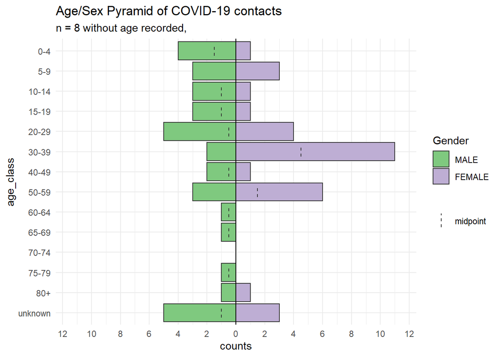

```r
contact_unknown_age <- sum(contacts$age_class == "unknown") # count unknown

contact_age_pyramid <-
apyramid::age_pyramid(data = contacts,
                      age_group = "age_class",
                      split_by = "gender") +
       labs(
       fill = "Gender",
       title = "Age/Sex Pyramid of COVID-19 contacts",
       subtitle = paste0("n = ", contact_unknown_age," without age recorded,")) +
     theme_minimal() # cleaner theme

contact_age_pyramid
```

We can also view other demographics such as occupational breakdown of registered contacts (in form of a pie chart).

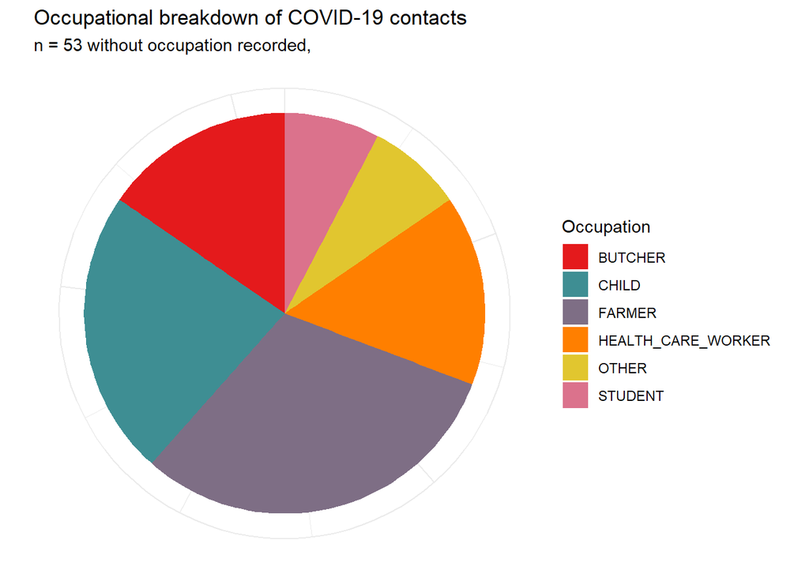

```r
contacts$occupation <- as.factor(contacts$occupation) # ensure occupation is a factor
contact_unknown_occupation <- sum(is.na(contacts$occupation) | contacts$occupation == "UNKNOWN") # count unknown
getPalette = colorRampPalette(brewer.pal(9, "Set1"))
color_count = length(unique(contacts$occupation)) # for color palette

contact_occupation_breakdown <- contacts %>%
  group_by(occupation) %>%
  count()

contact_occupation_pie_chart <-
  ggplot(subset(contact_occupation_breakdown, !is.na(occupation)), aes(x = "", y = n, fill = occupation)) +
  geom_bar(width = 1, stat = "identity") +
  coord_polar("y", start = 0) +
  theme_minimal() +
  scale_fill_manual(values = getPalette(color_count)) +
  labs(
       fill = "Occupation",
       title = "Occupational breakdown of COVID-19 contacts",
       subtitle = paste0("n = ", contact_unknown_occupation," without occupation recorded,")
       ) +
  theme(axis.line = element_blank(),
        axis.title = element_blank(),
        axis.text = element_blank())

contact_occupation_pie_chart
```

#### Contact Follow Up Data

We can also view the longitudinal follow-up data by summarizing it for a given contact or looking at the discrete follow up events over time. This could be viewed by contact tracer, supervision team and geographic area; and also by day and week.

A sample follow-up list could look like this, with one row for each follow-up generated.

| uuid | contact_id | contact_uuid | followup_status | followup_number | date_of_data_entry | date_of_followup | team_id | location_id | lat | long | geo_location_accurate | address | postal_code | city | telephone | email | admin_level | admin_0_location_id | admin_0_admin_level | admin_0_name | admin_0_code | admin_0_parent_location_id | admin_0_population_density | admin_0_lat | admin_0_long | admin_1_location_id | admin_1_admin_level | admin_1_name | admin_1_code | … |
| --- | --- | --- | --- | --- | --- | --- | --- | --- | --- | --- | --- | --- | --- | --- | --- | --- | --- | --- | --- | --- | --- | --- | --- | --- | --- | --- | --- | --- | --- | --- |
| 6c2cd53f-ca81-4876-9f6b-db8659702694 | CONTACT-2020-0012 | 245d864a-34df-46be-a93e-f96e95673d7c | SEEN_OK | 7 | 2020-06-23 | 2020-06-02 |  | SN001011002000000000 |  |  | False |  |  |  |  |  | 2 | SN001000000000000000 | 0 | Trainingland | TRAINING |  | 0 | 80.4559801 | 50.1710003 | SN001011000000000000 | 1 | Drums island | DRUMS | … |
| 67390c9c-f094-4b97-bdff-d234e114dcd4 | CONTACT-2020-0015 | 794c6a32-cf1f-4d3c-8b73-7bfb5922ed7b | NOT_ATTEMPTED | 8 | 2020-06-23 | 2020-06-03 |  | SN001014004000000000 |  |  | False | Main Street | 1234 | City |  |  | 2 | SN001000000000000000 | 0 | Trainingland | TRAINING |  | 0 | 80.4559801 | 50.1710003 | SN001014000000000000 | 1 | Brass island | BRA | … |
| b469a268-6ee5-495c-bed8-7624e8cb218a | CONTACT-2020-0015 | 794c6a32-cf1f-4d3c-8b73-7bfb5922ed7b | SEEN_OK | 6 | 2020-06-23 | 2020-06-01 |  | SN001014004000000000 |  |  | False | Main Street | 1234 | City |  |  | 2 | SN001000000000000000 | 0 | Trainingland | TRAINING |  | 0 | 80.4559801 | 50.1710003 | SN001014000000000000 | 1 | Brass island | BRA | … |
| 5cadba2b-a635-4bc7-bc0b-6334205c9054 | CONTACT-2020-0015 | 794c6a32-cf1f-4d3c-8b73-7bfb5922ed7b | SEEN_OK | 9 | 2020-06-23 | 2020-06-04 |  | SN001014004000000000 |  |  | False | Main Street | 1234 | City |  |  | 2 | SN001000000000000000 | 0 | Trainingland | TRAINING |  | 0 | 80.4559801 | 50.1710003 | SN001014000000000000 | 1 | Brass island | BRA | … |
| e4c9bba7-cc37-4caa-bda4-97e41a518c23 | CONTACT-2020-0015 | 794c6a32-cf1f-4d3c-8b73-7bfb5922ed7b | SEEN_OK | 7 | 2020-06-23 | 2020-06-02 |  | SN001014004000000000 |  |  | False | Main Street | 1234 | City |  |  | 2 | SN001000000000000000 | 0 | Trainingland | TRAINING |  | 0 | 80.4559801 | 50.1710003 | SN001014000000000000 | 1 | Brass island | BRA | … |
| 8756cc75-8b50-4a96-a344-c2a033e67dba | CONTACT-2020-0043 | efd9e740-71db-44ad-a3f9-6f072afbb604 | SEEN_OK | 1 | 2020-06-23 | 2020-06-03 |  | SN001011002000000000 |  |  | False |  |  |  |  |  | 2 | SN001000000000000000 | 0 | Trainingland | TRAINING |  | 0 | 80.4559801 | 50.1710003 | SN001011000000000000 | 1 | Drums island | DRUMS | … |
| 6e3d2db2-df54-4816-a729-eb9797e4dba8 | CONTACT-2020-0046 | f08f3f60-79b6-48f2-8932-bef3b7a365a4 | SEEN_OK | 2 | 2020-06-23 | 2020-06-05 |  |  |  |  |  |  |  |  |  |  |  |  |  |  |  |  |  |  |  |  |  |  |  | … |
| 0d59481c-a02b-4217-86cd-ea84b934f9ea | CONTACT-2020-0012 | 245d864a-34df-46be-a93e-f96e95673d7c | SEEN_OK | 6 | 2020-06-23 | 2020-06-01 |  | SN001011002000000000 |  |  | False |  |  |  |  |  | 2 | SN001000000000000000 | 0 | Trainingland | TRAINING |  | 0 | 80.4559801 | 50.1710003 | SN001011000000000000 | 1 | Drums island | DRUMS | … |
| a1e53cc6-5737-4a7a-a8ae-fe8f0098a29c | CONTACT-2020-0046 | f08f3f60-79b6-48f2-8932-bef3b7a365a4 | SEEN_OK | 1 | 2020-06-23 | 2020-06-04 |  |  |  |  |  |  |  |  |  |  |  |  |  |  |  |  |  |  |  |  |  |  |  | … |
| 76476906-71a5-4b26-acfb-2468670d3409 | CONTACT-2020-0043 | efd9e740-71db-44ad-a3f9-6f072afbb604 | SEEN_OK | 2 | 2020-06-23 | 2020-06-04 |  | SN001011002000000000 |  |  | False |  |  |  |  |  | 2 | SN001000000000000000 | 0 | Trainingland | TRAINING |  | 0 | 80.4559801 | 50.1710003 | SN001011000000000000 | 1 | Drums island | DRUMS | … |

[output cut: 40 more lines]

```r
followups <- followups %>%
  arrange(contact_uuid, desc(date_of_followup)) %>%    # arrange by date of follow-up; most recent first
  distinct(contact_uuid, .keep_all = TRUE)             # distinct to grab first row per unique contact uuid
```

For each follow-up, we have a follow-up STATUS (such as whether it was performed and if so, did they have symptoms or not). We can group by `followup_status` to see the frequency of each:

```r
followup_status <- followups %>%
     group_by(followup_status) %>%
     count()
```

| followup_status | n |
| --- | --- |
| MISSED | 1 |
| NOT_PERFORMED | 29 |
| SEEN_NOT_OK | 1 |
| SEEN_OK | 11 |

In order to force the followup status columns to always be the same, we can set an array below `statuscols` and then use this later. For demonstration I will add in another category “OTHER_RANDOM_STATUS”.

```r
statuscols <- c(MISSED  = 0,
                SEEN_NOT_OK = 0,
                SEEN_OK = 0,
                NOT_PERFORMED = 0,
                NOT_ATTEMPTED = 0,
                OTHER_RANDOM_STATUS = 0)
```

We can visualize a simple plot to show, over time, the status of all follow-ups, of those that were generated. *ggplot2* works best with “long” format, which it already is, but if we need to force in the extra status column one option is widening first with `pivot_wider()`; add in column via `add_column()`; then to again `pivot_longer()`.

```r
followup_status_daily <- followups %>%
     group_by(followup_status, date_of_followup) %>%
     count() %>%
     pivot_wider(names_from = followup_status,
                 values_from = n,
                 values_fill = list(n=0))
```

| date_of_followup | MISSED | NOT_PERFORMED | SEEN_NOT_OK | SEEN_OK |
| --- | --- | --- | --- | --- |
| 2020-06-01 | 1 | 0 | 0 | 6 |
| 2020-06-05 | 0 | 6 | 1 | 4 |
| 2020-06-29 | 0 | 1 | 0 | 0 |
| 2020-07-01 | 0 | 6 | 0 | 0 |
| 2020-07-03 | 0 | 1 | 0 | 0 |
| 2020-07-04 | 0 | 2 | 0 | 0 |
| 2020-07-06 | 0 | 6 | 0 | 0 |
| 2020-07-08 | 0 | 2 | 0 | 0 |
| 2020-08-21 | 0 | 1 | 0 | 0 |
| 2020-08-27 | 0 | 1 | 0 | 0 |

[output cut: 3 more lines]

Here we have for each day, the count of each follow-up status. In order to guard against categories being dropped, we can add the `statuscols` using `add_column()` - it will will be forced to 0 if no rows match this status.

```r
followup_status_daily <- followups %>%
     group_by(followup_status, date_of_followup) %>%
     count() %>%
     pivot_wider(names_from = followup_status,
                 values_from = n,
                 values_fill = list(n=0)) %>%
     add_column(!!!statuscols[!names(statuscols)%in% names(.)])  # check and add columns if one status doesn't exist
```

| date_of_followup | MISSED | NOT_PERFORMED | SEEN_NOT_OK | SEEN_OK | NOT_ATTEMPTED | OTHER_RANDOM_STATUS |
| --- | --- | --- | --- | --- | --- | --- |
| 2020-06-01 | 1 | 0 | 0 | 6 | 0 | 0 |
| 2020-06-05 | 0 | 6 | 1 | 4 | 0 | 0 |
| 2020-06-29 | 0 | 1 | 0 | 0 | 0 | 0 |
| 2020-07-01 | 0 | 6 | 0 | 0 | 0 | 0 |
| 2020-07-03 | 0 | 1 | 0 | 0 | 0 | 0 |
| 2020-07-04 | 0 | 2 | 0 | 0 | 0 | 0 |
| 2020-07-06 | 0 | 6 | 0 | 0 | 0 | 0 |
| 2020-07-08 | 0 | 2 | 0 | 0 | 0 | 0 |
| 2020-08-21 | 0 | 1 | 0 | 0 | 0 | 0 |
| 2020-08-27 | 0 | 1 | 0 | 0 | 0 | 0 |

[output cut: 3 more lines]

Now we can transform back to “long” format to prepare for plotting using `pivot_longer()`.

```r
followup_status_daily_long <- followups %>%
     group_by(followup_status, date_of_followup) %>%
     count() %>%
     pivot_wider(names_from = followup_status,
                 values_from = n,
                 values_fill = list(n=0)) %>%
     add_column(!!!statuscols[!names(statuscols)%in% names(.)]) %>% # check and add columns if one status doesn't exist
     pivot_longer(cols = -date_of_followup,             # pivot to long version but retain date_of_followup column
                  names_to = "daily_status",
                  values_to = "counts")
```

| date_of_followup | daily_status | counts |
| --- | --- | --- |
| 2020-06-01 | MISSED | 1 |
| 2020-06-01 | NOT_PERFORMED | 0 |
| 2020-06-01 | SEEN_NOT_OK | 0 |
| 2020-06-01 | SEEN_OK | 6 |
| 2020-06-01 | NOT_ATTEMPTED | 0 |
| 2020-06-01 | OTHER_RANDOM_STATUS | 0 |
| 2020-06-05 | MISSED | 0 |
| 2020-06-05 | NOT_PERFORMED | 6 |
| 2020-06-05 | SEEN_NOT_OK | 1 |
| 2020-06-05 | SEEN_OK | 4 |

[output cut: 68 more lines]

Now we can plot to show this over time.

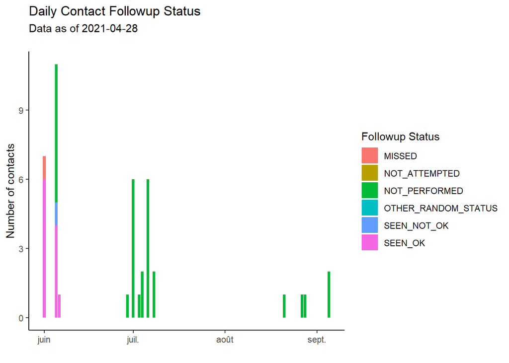

```r
graph_followup_status_daily_long <- followup_status_daily_long %>%
    ggplot(aes(x = date_of_followup, y = counts, fill = daily_status)) +
    geom_col(position = "stack") +
    theme_classic() +
    labs(x = "",
         y = "Number of contacts",
         title = "Daily Contact Followup Status",
         fill = "Followup Status",
         subtitle = paste0("Data as of ", Sys.Date(), "\n"))

graph_followup_status_daily_long
```

Perhaps this is being viewed on a daily of weekly basis for operational decision-making, and it’s better to do some more meaningful disaggregations by geographic area or team. We can do this following same approach as before, just swapping out `group_by()` variables.

```r
followup_status_regional <- followups %>%
     group_by(followup_status, admin_2_name, admin_1_name) %>%    # here instead we are using location var
     count() %>%
     pivot_wider(names_from = followup_status,
                 values_from = n,
                 values_fill = list(n=0)) %>%
     add_column(!!!statuscols[!names(statuscols)%in% names(.)]) %>%  # check and add columns if one status doesn't exist
     pivot_longer(cols = -(admin_2_name:admin_1_name),             # pivot to long version but retain location columns
                  names_to = "daily_status",
                  values_to = "counts")
```

| admin_2_name | admin_1_name | daily_status | counts |
| --- | --- | --- | --- |
|  |  | MISSED | 1 |
|  |  | NOT_PERFORMED | 25 |
|  |  | SEEN_NOT_OK | 1 |
|  |  | SEEN_OK | 10 |
|  |  | NOT_ATTEMPTED | 0 |
|  |  | OTHER_RANDOM_STATUS | 0 |
| Djembe | Drums island | MISSED | 0 |
| Djembe | Drums island | NOT_PERFORMED | 2 |
| Djembe | Drums island | SEEN_NOT_OK | 0 |
| Djembe | Drums island | SEEN_OK | 0 |

[output cut: 8 more lines]

Now we can graph and facet appropriately:

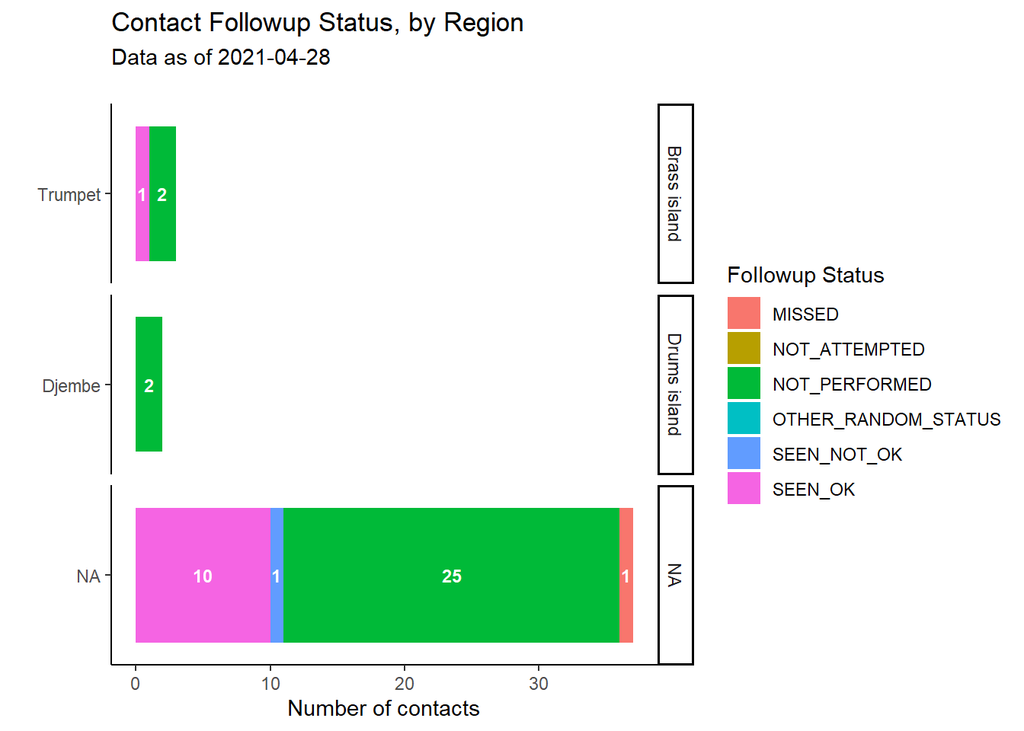

```r
graph_followup_status_regional <- followup_status_regional %>%
    ggplot(aes(x = reorder(admin_2_name,counts),
               y = counts,
               fill = daily_status,
               label = ifelse(counts>0, counts, NA)  # add in label of counts for easier reading
               )) +
    geom_col(position = "stack") +
    geom_text(size = 3, position = position_stack(vjust = 0.5),
               color = "white", check_overlap = TRUE, fontface = "bold") + # formatting for text labeling
    coord_flip() +
    theme_classic() +
    labs(x = "",
         y = "Number of contacts",
         title = "Contact Followup Status, by Region",
         fill = "Followup Status",
         subtitle = paste0("Data as of ", Sys.Date(), "\n")) +
     facet_wrap(~admin_1_name, strip.position = "right", scales = "free_y", ncol = 1)  # add admin_1 names on right

graph_followup_status_regional
```

If this was disaggregated by contact tracer, perhaps we would want to add a threshold line to display total # contacts that normally one person or area/team can handle, and how the current workload compares. We just do this by using `geom_hline()` function.

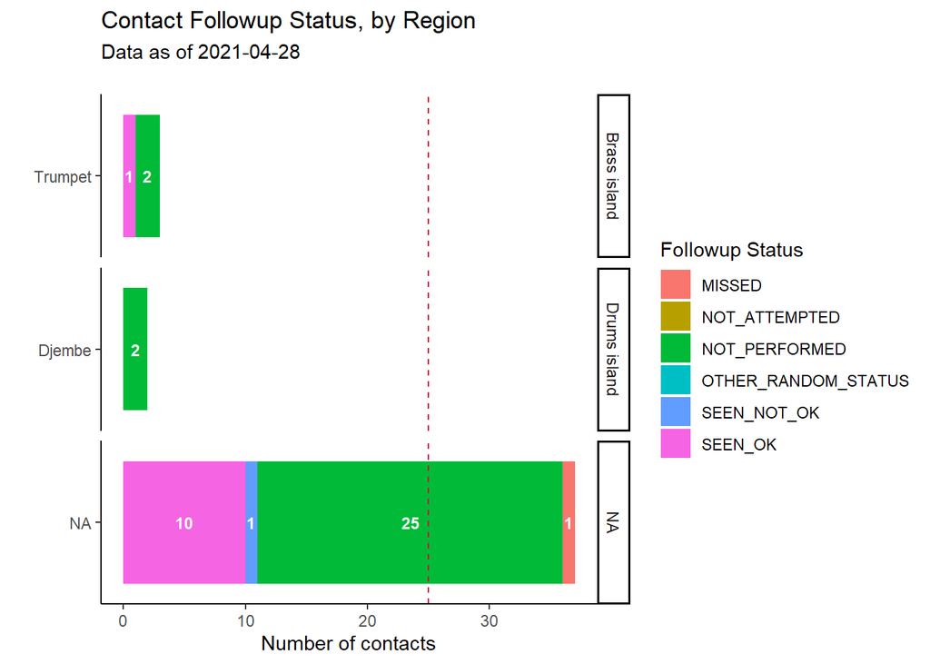

```r
graph_followup_status_regional <-
     graph_followup_status_regional +
     geom_hline(aes(yintercept=25), color="#C70039", linetype = "dashed") # fictitious threshold at 25 contacts

graph_followup_status_regional
```

#### KPI Tables

There are a number of different Key Performance Indicators (KPIs) that can be calculated and tracked at varying levels of disaggregations and across different time periods to monitor contact tracing performance. Once you have the calculations down and the basic table format; it is fairly easy to swap in and out different KPIs.

There are numerous sources of contact tracing KPIs, such as this one from [ResolveToSaveLives.org](https://contacttracingplaybook.resolvetosavelives.org/checklists/metrics). The majority of the work will be walking through your data structure and thinking through all of the inclusion/exclusion criteira. We show a few examples below; using Go.Data metadata structure:

| Category | Indicator | Go.Data Numerator | Go.Data Denominator |
| --- | --- | --- | --- |
| Process Indicator - Speed of Contact Tracing | % cases interviewed and isolated within 24h of case report | COUNT OF `case_id` WHERE (`date_of_reporting` - `date_of_data_entry`) < 1 day AND (`isolation_startdate` - `date_of_data_entry`) < 1 day | COUNT OF `case_id` |
| Process Indicator - Speed of Contact Tracing | % contacts notified and quarantined within 24h of elicitation | COUNT OF `contact_id` WHERE `followup_status` == “SEEN_NOT_OK” OR “SEEN_OK” AND `date_of_followup` - `date_of_reporting` < 1 day | COUNT OF `contact_id` |
| Process Indicator - Completeness of Testing | % new symptomatic cases tested and interviewed within 3 days of onset of symptoms | COUNT OF `case_id` WHERE (`date_of_reporting` - `date_of_onset`) < =3 days | COUNT OF `case_id` |
| Outcome Indicator - Overall | % new cases among existing contact list | COUNT OF `case_id` WHERE `was_contact` == “TRUE” | COUNT OF `case_id` |

Below we will walk through a sample exercise of creating a nice table visual to show contact follow-up across contact tracers using *formattable* package.

To better summarize, we can do some joins of some sub-sets of the followups table (1 row per follow-up), with the contacts linelist (1 row per contact). For instance, we can scan the entire followups list to just identify contacts that were “SEEN” at all (either Seen-OK or Seen-Not Ok), and also the last followup generated for each contact.

```r
contacts_seen_ever <- followups %>%
  filter(followup_status == "SEEN_OK" | followup_status == "SEEN_NOT_OK") %>% # filter for only those followups where contact was reached
  arrange(contact_uuid, desc(date_of_followup)) %>%                           # de-duplicate to get only most recent
  distinct(contact_uuid, .keep_all = TRUE) %>%
  select(uuid = contact_uuid,
         contact_id,
         date_of_last_followup_seen = date_of_followup)

contacts_last_visit <- followups %>%
  arrange(contact_uuid, desc(date_of_followup)) %>%
  distinct(contact_uuid, .keep_all = TRUE) %>%                                # similarly, de-duplicate to get only most recent
  select(uuid = contact_uuid,
         contact_id,
         date_of_last_followup = date_of_followup,
         status_of_last_followup = followup_status)
```

| uuid | contact_id | date_of_last_followup_seen |
| --- | --- | --- |
| 01be9322-7ecd-4d8d-858c-49dc048aabe5 | CONTACT-2020-0055 | 2020-06-05 |
| 4b501c81-7dab-4de7-b8a7-3124c55ac17f | CONTACT-2020-0042 | 2020-06-05 |
| 4fcdb57b-ec1e-47ba-a938-350ae798d8d1 | CONTACT-2020-0006 | 2020-06-01 |
| 726d34f9-6d89-41e3-89ef-85093c6f4b61 | CONTACT-2020-0044 | 2020-06-05 |
| 874c5b14-f983-456b-a329-91ecfc09fd46 | CONTACT-2020-0004 | 2020-06-01 |
| 95941c2d-b94a-4c10-b518-59444cf3ab01 | CONTACT-2020-0005 | 2020-06-01 |
| a3a7cacb-96fb-4f8e-8870-2817c38b2272 | CONTACT-2020-0029 | 2020-06-05 |
| aeb0f75d-255a-4f54-a900-9f404e3af7b1 | CONTACT-2020-0039 | 2020-06-06 |
| aff64c8f-32e1-428d-82a4-527f2b16d1d5 | CONTACT-2020-0060 | 2020-06-05 |
| b6b2d286-6a91-4bb7-a65d-90353ada5d2c | CONTACT-2020-0003 | 2020-06-01 |

[output cut: 2 more lines]

| uuid | contact_id | date_of_last_followup | status_of_last_followup |
| --- | --- | --- | --- |
| 01be9322-7ecd-4d8d-858c-49dc048aabe5 | CONTACT-2020-0055 | 2020-06-05 | SEEN_OK |
| 0c63a125-8474-439b-af1c-4d12d8b9c6b3 | CONTACT-2020-0054 | 2020-07-01 | NOT_PERFORMED |
| 1705a7f2-d9ee-4d3c-bf0f-24a2c3909aea | CONTACT-2020-0057 | 2020-06-05 | NOT_PERFORMED |
| 178a26dd-c0f7-49c7-bca1-dc567d58409c | CONTACT-2020-0035 | 2020-07-01 | NOT_PERFORMED |
| 1fbf5c0f-5c68-4b30-9a9e-276c308e5cff |  | 2020-09-05 | NOT_PERFORMED |
| 245d864a-34df-46be-a93e-f96e95673d7c | CONTACT-2020-0012 | 2020-08-21 | NOT_PERFORMED |
| 2cf4928b-2899-45ad-9cc4-6663e5964aea | CONTACT-2020-0036 | 2020-07-03 | NOT_PERFORMED |
| 3da25d3b-c46f-47ab-8f88-18410acb57b5 | CONTACT-2020-0050 | 2020-07-01 | NOT_PERFORMED |
| 4b501c81-7dab-4de7-b8a7-3124c55ac17f | CONTACT-2020-0042 | 2020-06-05 | SEEN_OK |
| 4dc896e4-bc11-478e-81b1-f08f5965161c | CONTACT-2020-0040 | 2020-06-05 | NOT_PERFORMED |

[output cut: 32 more lines]

Then we can join these back to full contacts linelist so that we have these new descriptors, per contact.

```r
database_date = max(followups$date_of_followup)

contact_linelist_status <- contacts %>%
  left_join(select                                          # left join to get date of last followup where contact was SEEN
            (contacts_seen_ever, uuid, date_of_last_followup_seen),
            by = "uuid") %>%
  left_join(select                                          # left join to get date and status of last followup generated regardless of status
            (contacts_last_visit, uuid, date_of_last_followup, status_of_last_followup),
            by = "uuid") %>%
  mutate_if(is_character, funs(na_if(.,""))) %>%
  mutate(days_since_followup_seen = difftime(database_date,
                                        date_of_last_followup_seen,
                                        units = "day")) %>%         # calculate days past since followup seen
  mutate(days_since_exp = difftime(database_date,
                                   date_of_last_contact,
                                   units = "day")) %>%
  mutate(seen_with_signs = case_when(
                                  status_of_last_followup == "SEEN_NOT_OK"
                                  & date_of_last_followup == database_date ~ TRUE,
                                  TRUE ~ FALSE)) %>%
  mutate(seen_without_signs = case_when(
                                  status_of_last_followup == "SEEN_OK"
                                  & date_of_last_followup == database_date ~ TRUE,
                                  TRUE ~ FALSE)) %>%
  mutate(missed = case_when(
                                  status_of_last_followup == "MISSED"
                                  & date_of_last_followup == database_date ~ TRUE,
                                  TRUE ~ FALSE)) %>%
  mutate(no_action = case_when(
                                  (status_of_last_followup == "NOT_ATTEMPTED" |
                                    status_of_last_followup == "NOT_PERFORMED" )
                                  & date_of_last_followup == database_date ~ TRUE,
                                  TRUE ~ FALSE)) %>%

  mutate(lost_to_followup = case_when(
                                  days_since_followup_seen >= 3 ~ TRUE,
                                  TRUE ~ FALSE)) %>%
  mutate(second_week_followup = case_when(
                                  days_since_exp < 15
                                  & days_since_exp >= 8 ~ TRUE,
                                  TRUE ~ FALSE)) %>%
  mutate(first_week_followup = case_when(
                                  days_since_exp < 8 ~ TRUE,
                                  TRUE ~ FALSE)) %>%
  mutate(never_seen = !(uuid %in% contacts_seen_ever$uuid))
```

Build final table like this, using *formattable* and *kableExtra*

```r
tab_contact_status <- contact_linelist_status %>%
  filter(!is.na(admin_2_name)) %>%
  group_by(admin_2_name) %>%
  summarize(
    total_reg_contacts = n(),
    total_active_contacts = sum(contact_status == "UNDER_FOLLOW_UP"),
    total_contacts_became_case = sum(contact_status == "BECAME_CASE"),
    seen_with_signs = sum(seen_with_signs),
    seen_without_signs = sum(seen_without_signs),
    missed = sum(missed),
    no_action = sum(no_action),
    second_week = sum(second_week_followup),
    first_week = sum(first_week_followup),
    lost_to_followup = sum(lost_to_followup),
    never_seen = sum(never_seen)
            ) %>%
  arrange(desc(total_reg_contacts)) %>%
  select(
    `Admin 2` = admin_2_name,
    `Registered contacts` = total_reg_contacts,
    `Active contacts` = total_active_contacts,
    `Became case` = total_contacts_became_case,
    `In first week` = first_week,
    `In second week` = second_week,
    `Lost to follow up` = lost_to_followup,
    `Never seen` = never_seen,
    `Followed up - signs`= seen_with_signs,
    `Followed up - no signs` = seen_without_signs,
    `Not Followed up` = no_action,

  )

formattable_tab_contact_status <-tab_contact_status %>%

  mutate(
    `Admin 2` = formatter("span", style = ~ formattable::style(
      color = ifelse(`Admin 2` == NA, "red", "grey"),
      font.weight = "bold",font.style = "italic"))(`Admin 2`),
    `Followed up - signs`= color_tile("white", "orange")(`Followed up - signs`),
    `Followed up - no signs`= color_tile("white", "#A0E2BD")(`Followed up - no signs`),
    `Became case`= color_tile("white", "grey")(`Became case`),
    `Lost to follow up`= color_tile("white", "grey")(`Lost to follow up`),
    `Never seen`= color_tile("white", "red")(`Never seen`),
    `Active contacts` = color_tile("white", "#81A4CE")(`Active contacts`)
  ) %>%
  kable("html", escape = F, align =c("l","c","c","c","c","c","c","c","c","c","c")) %>%
  kable_styling("hover", full_width = FALSE) %>%
  add_header_above(c(" " = 3,
                     "Of contacts currently under follow up" = 5,
                     "Status of last visit" = 3))

formattable_tab_contact_status
```

| Admin 2 | Registered contacts | Active contacts | Of contacts currently under follow up Became case | Of contacts currently under follow up In first week | Of contacts currently under follow up In second week | Of contacts currently under follow up Lost to follow up | Of contacts currently under follow up Never seen | Status of last visit Followed up - signs | Status of last visit Followed up - no signs | Status of last visit Not Followed up |
| --- | --- | --- | --- | --- | --- | --- | --- | --- | --- | --- |
| Djembe | 3 | 1 | 0 | 0 | 0 | 0 | 3 | 0 | 0 | 0 |
| Trumpet | 3 | 1 | 0 | 0 | 0 | 1 | 2 | 0 | 0 | 0 |
| Venu | 2 | 0 | 2 | 0 | 0 | 0 | 2 | 0 | 0 | 0 |
| Congas | 1 | 0 | 1 | 0 | 0 | 0 | 1 | 0 | 0 | 0 |
| Cornet | 1 | 0 | 1 | 0 | 0 | 0 | 1 | 0 | 0 | 0 |

#### Transmission Matrices

As discussed in the [Heat plots] page, you can view a matrix of “who infected whom”.

When new contacts are created, Go.Data stores this relationship information in the “relationships” API endpoint; and we can see the dataset below. This means that we can create a heatmap with relatively few steps given each contact is already joined to it’s source case.

```r
# display the first 50 rows of relationships data as a table
DT::datatable(head(relationships, 50), rownames = FALSE, filter="top", options = list(pageLength = 5, scrollX=T), class = 'white-space: nowrap' )
```

| uuid | source_uuid | source_visualid | source_gender | date_of_last_contact | date_of_data_entry | source_age | target_uuid | target_visualid | target_gender | target_age | exposure_type | context_of_exposure | exposure_frequency | certainty_level | exposure_duration | relation_detail | cluster | is_contact_date_estimated | comment | createdBy |
| --- | --- | --- | --- | --- | --- | --- | --- | --- | --- | --- | --- | --- | --- | --- | --- | --- | --- | --- | --- | --- |
| 08fdb185-09ae-4d04-9ea0-a4011d16377c | c498a75c-3684-4cef-b707-f0c0a3b0af08 | CASE-2020-0016 | Female | 2020-06-24 | 2020-06-08 | 80 | 5a891dab-b7f6-4468-b5b4-372d3c0c1d0b | CONTACT-2020-0027 | Male | 15 | Direct physical contact |  |  | 3 - High |  |  |  | False |  | 808ef7ce-5e38-4104-8c78-5e4fb0607f0a |
| 0cb523f0-182d-4660-b61b-b747dc0a61f6 | 3b2825b8-9ac5-4c9e-83df-d37ff9205463 |  |  | 2020-05-02 | 2020-06-08 |  | cf356e61-d0c8-4a06-883a-48311c2b00c8 | CASE-2020-0014 | Male | 54 |  |  |  | 3 - High |  |  |  | False |  | 808ef7ce-5e38-4104-8c78-5e4fb0607f0a |
| 0ee04c70-edb6-4aa9-8d4f-f70f3d8a0491 | 8fd215fd-84d5-47bc-881f-0a9cb3939c15 |  |  | 2020-06-15 | 2020-06-08 |  | 834cf8d0-a431-41ef-8b0d-7272420805b0 | CASE-2020-0031 | Male | 20 |  |  |  | 3 - High |  |  |  | False |  | 808ef7ce-5e38-4104-8c78-5e4fb0607f0a |
| 111577e4-c40a-49c2-9cb1-ab9d71ec32e1 | c46b7b3f-121d-4cf8-aff5-34750cc3442b | CASE-2020-0045 | Female | 2020-07-27 | 2020-06-10 | 34 | 6b054481-e8ea-46a7-bce0-9afcbc70f66c | CASE-2020-0021 | Male | 46 |  |  |  | 3 - High |  |  |  | False |  | 17a1db0d-2deb-4f2a-a938-a90de2fba4df |
| 112dc9fb-362c-49dd-b79b-55a95edc8439 | 3225fe6a-01db-4710-8cb7-1863e1bfd968 | CASE-2020-0004 | Male | 2020-06-05 | 2020-06-08 | 43 | d040a42e-4bd5-4c20-9d53-a3b191a8b984 | CONTACT-2020-0020 | Female | 32 | Indirect contact (touched contaminated surface/materials/fomites etc.) |  |  | 3 - High |  |  |  | False |  | 808ef7ce-5e38-4104-8c78-5e4fb0607f0a |
| 1322a8d8-c980-4a58-bc11-e0660df15684 | ee334fea-ee55-499d-adf8-74e25cfa7a8b | CASE-2020-0010 | Female | 2020-06-05 | 2020-06-08 | 37 | dc43d898-c425-4767-a9db-7e571ff02973 | CONTACT-2020-0038 | Male | 7 | Direct non-physical contact (within 1 meter) |  |  | 3 - High |  |  |  | False |  | 808ef7ce-5e38-4104-8c78-5e4fb0607f0a |
| 197fc778-04d0-4005-a962-cedac2330f3b | 60dfe39f-d6de-47bf-96e0-8f989cad4b10 |  |  | 2020-08-19 | 2020-08-20 |  | d67ec12d-71c6-4c77-bb8f-6b13bbdbf9b8 | CASE-2020-0036 | Female | 40 |  |  |  | 1 - Low |  |  |  | False |  | adf6e5ca-77ac-4eaa-84fb-4be588c5d74a |
| 19afcffa-ed35-4dc5-b4a7-9b49b932a09c | 3083e9b6-9d56-4eed-931a-c3aad508de3f | CASE-2020-0034 | Male | 2020-06-20 | 2020-06-08 | 20 | c6a11bd1-7c47-4429-9069-cf8cf2a28d92 | CONTACT-2020-0059 | Female | 97 | Direct physical contact |  |  | 3 - High |  |  |  | False |  | 808ef7ce-5e38-4104-8c78-5e4fb0607f0a |
| 1c0d40d2-8a5d-48bb-b833-e6bb7ae9516e | 60dfe39f-d6de-47bf-96e0-8f989cad4b10 |  |  | 2020-08-19 | 2020-08-20 |  | 49f81f55-e27e-4376-8fa6-76c10326f464 | CASE-2020-0037 | Female | 80 |  |  |  | 3 - High |  |  |  | False |  | adf6e5ca-77ac-4eaa-84fb-4be588c5d74a |
| 1d159658-0b2c-4ba2-b2bf-d9b3ca33f816 | 49f81f55-e27e-4376-8fa6-76c10326f464 | CASE-2020-0037 | Female | 2020-09-02 | 2020-09-03 | 80 | 6e7d3c66-bbd5-4858-b55f-d3e9e27b900a |  | Male | 0 | Direct physical contact |  | 11-20 Times | 3 - High |  |  |  | False |  | d2c16590-e538-4f15-9f2c-1ec069307218 |

[output cut: 40 more lines]

We can grab the few variables we need and add age-categories for sources (cases) and targets (contacts).

```r
heatmap_ages <- relationships %>%
  filter(!is.na(source_visualid) & !is.na(target_visualid)) %>%
  select(source_visualid, source_age, target_visualid, target_age) %>%
  # WHO recommended age categories, updated Sept 2020
  mutate(
    source_age_class = factor(
      case_when(
        source_age <= 4 ~ "0-4",
        source_age <= 9 ~ "5-9",
        source_age <= 14 ~ "10-14",
        source_age <= 19 ~ "15-19",
        source_age <= 29 ~ "20-29",
        source_age <= 39 ~ "30-39",
        source_age <= 49 ~ "40-49",
        source_age <= 59 ~ "50-59",
        source_age <= 64 ~ "60-64",
        source_age <= 69 ~ "65-69",
        source_age <= 74 ~ "70-74",
        source_age <= 79 ~ "75-79",
        is.finite(source_age) ~ "80+",
        TRUE ~ "unknown"
      ), levels = c(
        "0-4",
        "5-9",
        "10-14",
        "15-19",
        "20-29",
        "30-39",
        "40-49",
        "50-59",
        "60-64",
        "65-69",
        "70-74",
        "75-79",
        "80+",
        "unknown"
      )),
    source_age_class = factor(
      source_age_class,
      levels = rev(levels(source_age_class)))) %>%

     mutate(
    target_age_class = factor(
      case_when(
        target_age <= 4 ~ "0-4",
        target_age <= 9 ~ "5-9",
        target_age <= 14 ~ "10-14",
        target_age <= 19 ~ "15-19",
        target_age <= 29 ~ "20-29",
        target_age <= 39 ~ "30-39",
        target_age <= 49 ~ "40-49",
        target_age <= 59 ~ "50-59",
        target_age <= 64 ~ "60-64",
        target_age <= 69 ~ "65-69",
        target_age <= 74 ~ "70-74",
        target_age <= 79 ~ "75-79",
        is.finite(target_age) ~ "80+",
        TRUE ~ "unknown"
      ), levels = c(
        "0-4",
        "5-9",
        "10-14",
        "15-19",
        "20-29",
        "30-39",
        "40-49",
        "50-59",
        "60-64",
        "65-69",
        "70-74",
        "75-79",
        "80+",
        "unknown"
      )),
    target_age_class = factor(
      target_age_class,
      levels = rev(levels(target_age_class))))
```

| source_visualid | source_age | target_visualid | target_age | source_age_class | target_age_class |
| --- | --- | --- | --- | --- | --- |
| CASE-2020-0016 | 80 | CONTACT-2020-0027 | 15 | 80+ | 15-19 |
| CASE-2020-0045 | 34 | CASE-2020-0021 | 46 | 30-39 | 40-49 |
| CASE-2020-0004 | 43 | CONTACT-2020-0020 | 32 | 40-49 | 30-39 |
| CASE-2020-0010 | 37 | CONTACT-2020-0038 | 7 | 30-39 | 5-9 |
| CASE-2020-0034 | 20 | CONTACT-2020-0059 | 97 | 20-29 | 80+ |
| CASE-2020-0005 | 23 | CASE-2020-0015 | 38 | 20-29 | 30-39 |
| CASE-2020-0002 | 52 | CONTACT-2020-0009 | 18 | 50-59 | 15-19 |
| CASE-2020-0001 | 49 | CASE-2020-0008 | 7 | 40-49 | 5-9 |
| CASE-2020-0004 | 43 | CONTACT-2020-0018 | 78 | 40-49 | 75-79 |
| CASE-2020-0012 | 80 | CONTACT-2020-0029 |  | 80+ | unknown |

[output cut: 40 more lines]

As described previously, we create cross-tabulation;

```r
cross_tab <-
      table(source_cases = heatmap_ages$source_age_class,
      target_cases = heatmap_ages$target_age_class)
```

convert into long format with proportions;

```r
long_prop <- data.frame(prop.table(cross_tab))
```

and create a heat-map for age.

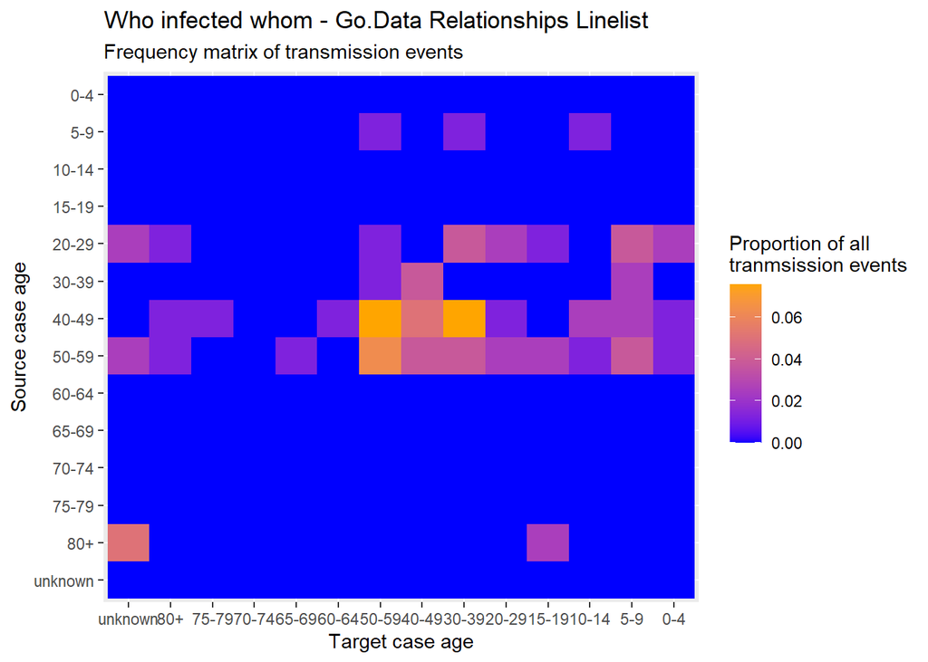

```r
ggplot(data = long_prop)+       # use long data, with proportions as Freq
  geom_tile(                    # visualize it in tiles
    aes(
      x = target_cases,         # x-axis is case age
      y = source_cases,     # y-axis is infector age
      fill = Freq))+            # color of the tile is the Freq column in the data
  scale_fill_gradient(          # adjust the fill color of the tiles
    low = "blue",
    high = "orange")+
  labs(                         # labels
    x = "Target case age",
    y = "Source case age",
    title = "Who infected whom - Go.Data Relationships Linelist",
    subtitle = "Frequency matrix of transmission events",
    fill = "Proportion of all\ntranmsission events"     # legend title
  )
```

## Resources

https://github.com/WorldHealthOrganization/godata/tree/master/analytics/r-reporting

https://worldhealthorganization.github.io/godata/

https://community-godata.who.int/